# Covid vaccines and social media influence

Paloma Guth Kronbauer, Sat Barseghyan, Kaashya Khandelwal

12/15/2023

# Research Background: Analyzing the Influence of Social Media on COVID-19 Vaccination Uptake

The COVID-19 pandemic has had an unprecedented global impact, prompting swift efforts to develop and administer vaccines to curb the spread of the virus. As vaccination campaigns rolled out worldwide, the role of social media in shaping public perceptions, attitudes, and behaviors towards COVID-19 vaccines became increasingly evident. In our data science project, we aim to conduct a comprehensive analysis of COVID-19 vaccinations, coupled with sentiment analysis of related tweets, and a global comparison to understand the influence of social media on vaccination trends.

## Rationale for the study:

- Rapid Information Dissemination: Social media platforms serve as rapid channels for information dissemination. During the pandemic, these platforms played a pivotal role in circulating updates about vaccine development, distribution, and effectiveness. Understanding how information spreads on social media is crucial for comprehending its impact on public awareness and vaccine acceptance.
- Vaccine Hesitancy: Vaccine hesitancy, fueled in part by misinformation and myths, emerged as a significant challenge in achieving widespread vaccination coverage. By analyzing social media content, we aim to identify prevalent narratives and sentiments that may contribute to vaccine hesitancy, enabling targeted interventions to address misinformation.
- Public Sentiment Analysis: Tweets and posts on social media platforms often reflect public sentiment towards COVID-19 vaccinations. Our analysis seeks to uncover not only positive or negative sentiments but also the underlying factors influencing public opinions. This nuanced understanding is vital for public health campaigns and communication strategies.
- Global Comparison: Beyond analysis that spanned both ends of the sentiment spectrum, examining countries with the highest number of negative comments as well as those with the most positive comments, our project includes a global perspective to compare vaccination trends and sentiments across regions. This broader view allows us to identify common patterns, global challenges, and potential areas for collaborative efforts in enhancing vaccine uptake.

By conducting this multifaceted analysis, our goal is to provide data-driven insights that contribute to the understanding of the complex interplay between social media, public perceptions, and COVID-19 vaccination outcomes. Through this research, we aim to inform public health strategies and communication initiatives that can foster greater vaccine acceptance and contribute to the global fight against the COVID-19 pandemic.

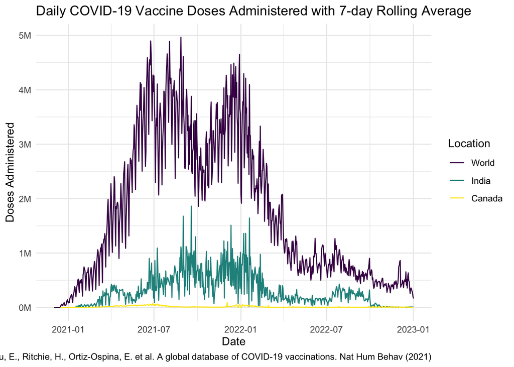

Fig 1. A plot of COVID-19 vaccinations.

# Country with most positive comments - India:

## Analysis of COVID-19-Related Tweets in India:

The dataset under consideration comprises text data extracted from tweets related to COVID-19 in India. The goal of this analysis is to uncover prevalent themes and patterns within the textual content, shedding light on the most frequently mentioned words and topics.

- Data Preprocessing:

To ensure a clean and focused analysis, we performed extensive text preprocessing on the dataset. This involved the removal of URLs, Twitter mentions, special characters, line breaks, punctuation, and numeric values. Additionally, common English stopwords were eliminated, and the remaining text was converted to lowercase for consistency.

- Term Frequency Analysis

Utilizing the processed text data, we generated a term-document matrix (TDM) to quantify the frequency of each word across the entire corpus. The resulting matrix was transformed into a data frame, allowing us to create a word cloud that visually represents the most frequently occurring terms.

## Wordcloud Insights

[figure not shown]

Fig 2. India COVID tweets word cloud

The word cloud provides an immediate visual overview of the dominant themes in COVID-19-related tweets. The size and color intensity of each word in the cloud correspond to its frequency in the dataset.

## Sentimental analysis insight

In the sentiment analysis plot, we observe an overarching positive sentiment towards vaccinations, as the analysis delves into the sentiments expressed in tweets related to vaccination in India. Notably, the data reveals a prevailing positive sentiment, with a noteworthy concentration of tweets exhibiting elevated sentiment scores. Specifically, among these, a distinctive set of tweets, exemplified by Tweet ID ~7500, stands out prominently with an exceptionally high sentiment score of 5.0, presenting a striking contrast to the general sentiment trends observed in the broader data set. This unique insight sheds light on the diverse range of sentiments expressed within the discourse on vaccinations, emphasizing the nuanced nature of public opinion in this particular context.

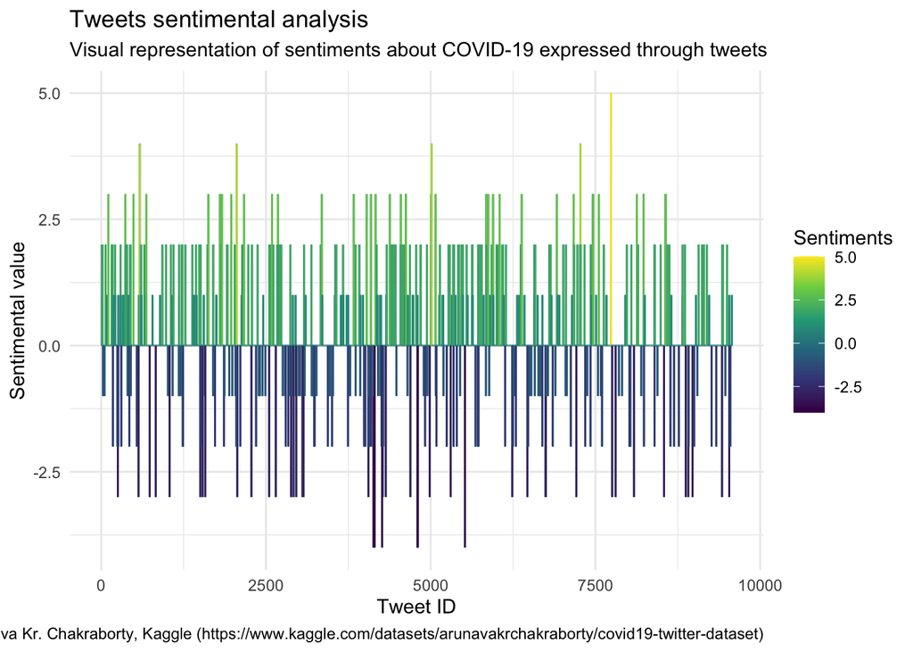

Fig 3. Sentimental analysis line chart about COVID tweets in India

# Country with most negative comments:

## Analysis of COVID-19-Related Tweets in Canada

The dataset under consideration consists of text data extracted from tweets related to COVID-19 in Canada. The primary objective of this analysis is to unravel prevalent themes and discourse patterns within the textual content, offering valuable insights into the most frequently discussed topics.

- Data Preprocessing:

To ensure a focused and meaningful analysis, extensive text preprocessing was conducted on the dataset. This involved the removal of URLs, Twitter mentions, special characters, line breaks, punctuation, and numeric values. Common English stopwords were also eliminated, and the remaining text was converted to lowercase to maintain consistency.

- Term Frequency Analysis:

Leveraging the processed text data, we constructed a term-document matrix (TDM) to quantify the frequency of each word across the entire corpus. The resulting matrix was then transformed into a data frame, facilitating the creation of a word cloud that visually encapsulates the most frequently occurring terms.

## Word Cloud Insights:

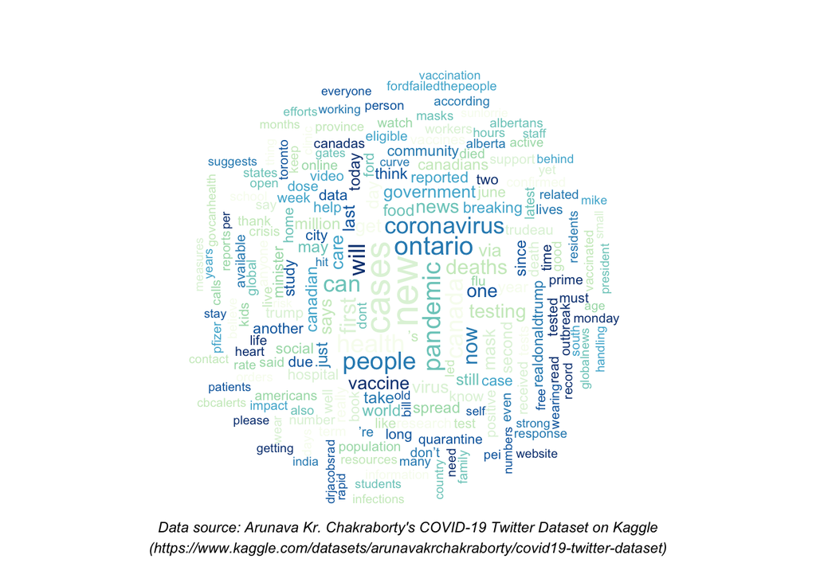

Fig 4. Canada COVID tweets word cloud

The resulting word cloud serves as a visual representation of the dominant themes within COVID-19-related tweets in Canada. Each word’s size and color intensity correspond to its frequency in the dataset, providing an immediate and impactful overview.

## Sentimental Analysis Insights:

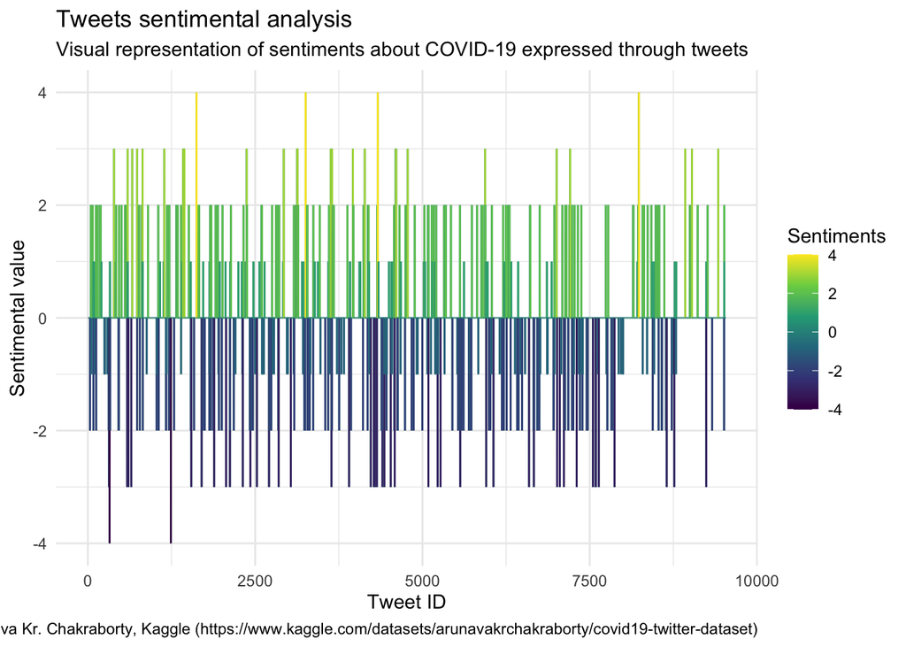

Fig 5. Sentimental analysis line chart about COVID tweets in Canada

# Conclusion

In this data science project, we delved into the intricate interplay between social media and COVID-19 vaccination trends across three distinct countries: India, Canada, and a global perspective. The overarching objective was to decipher the influence of social media on public perceptions, attitudes, and behaviors related to COVID-19 vaccines.

## Implications and Future Directions:

- Policy Recommendations: The insights obtained from this analysis can inform policymakers, public health officials, and communication strategists. Tailored interventions addressing specific concerns or misconceptions identified in the analysis can contribute to more effective vaccination campaigns.
- Continued Monitoring: Social media remains a dynamic platform, and public sentiments are subject to change. Continuous monitoring and analysis of social media trends are essential for adapting strategies and interventions in real-time.
- Collaborative Efforts: The global comparison highlights the importance of collaborative efforts in addressing common challenges. Sharing best practices and lessons learned can contribute to a more coordinated and impactful global response to the ongoing pandemic.

In conclusion, this project serves as a data-driven exploration into the intricate relationship between social media dynamics and COVID-19 vaccination outcomes. The findings and insights obtained aim to contribute meaningfully to the ongoing efforts to enhance vaccine acceptance and combat the global COVID-19 pandemic.